| title: “C5_W4_A2” |
| --- |
| author: “Lakshay Sharma” |
| date: “10/07/2019” |
| output: |
| html_document: |
| keep_md: true |

# **Reproducible Research Course Project-2**

## **Synopsis:**

Storms and other severe weather events can cause both public health and economic problems for communities and municipalities. Many severe events can result in fatalities, injuries, and property damage, and preventing such outcomes to the extent possible is a key concern. This project involves exploring the U.S. National Oceanic and Atmospheric Administration’s (NOAA) storm database. This database tracks characteristics of major storms and weather events in the United States, including when and where they occur, as well as estimates of any fatalities, injuries, and property damage.

## Purpose

#### The purpose of this assignment is:-

1.to make us learn to generate RMarkdown document 2.to know the importance of reproducibility 3.to analyse the data and produce answers for the given questions

## Import Libraries and Set Default Settings :-

#### Preprocessing and Downloading the Data

```r
temp <- tempfile()

if(!file.exists("/StormData.csv.bz2"))
{ download.file("https://d396qusza40orc.cloudfront.net/repdata%2Fdata%2FStormData.csv.bz2",          destfile="./StormData.csv.bz2")
}

if(!file.exists("StormData.csv"))
{ unzip2("StormData.csv.bz2","StormData.csv",remove=F)
}
```

#### Loading the Data

```r
  storm <- read.csv("StormData.csv",header=TRUE,sep=",")
  head(storm)
```

```
##   STATE__           BGN_DATE BGN_TIME TIME_ZONE COUNTY COUNTYNAME STATE
## 1       1  4/18/1950 0:00:00     0130       CST     97     MOBILE    AL
## 2       1  4/18/1950 0:00:00     0145       CST      3    BALDWIN    AL
## 3       1  2/20/1951 0:00:00     1600       CST     57    FAYETTE    AL
## 4       1   6/8/1951 0:00:00     0900       CST     89    MADISON    AL
## 5       1 11/15/1951 0:00:00     1500       CST     43    CULLMAN    AL
## 6       1 11/15/1951 0:00:00     2000       CST     77 LAUDERDALE    AL
##    EVTYPE BGN_RANGE BGN_AZI BGN_LOCATI END_DATE END_TIME COUNTY_END
## 1 TORNADO         0                                               0
## 2 TORNADO         0                                               0
## 3 TORNADO         0                                               0
## 4 TORNADO         0                                               0
## 5 TORNADO         0                                               0
## 6 TORNADO         0                                               0
##   COUNTYENDN END_RANGE END_AZI END_LOCATI LENGTH WIDTH F MAG FATALITIES
```

[output cut: 20 more lines]

## **RESULTS**

### 1.With respect to the Population Health, there are two damages caused : **fatalities and injuries**.

```r
fatalInjuries <- aggregate(FATALITIES ~ EVTYPE, data=storm , FUN=sum , na.rm=TRUE)
fatalInjuries  <- fatalInjuries[with(fatalInjuries,order(-FATALITIES)),]
fatalInjuries  <- head(fatalInjuries,20)
print(fatalInjuries )
```

```
##                      EVTYPE FATALITIES
## 834                 TORNADO       5633
## 130          EXCESSIVE HEAT       1903
## 153             FLASH FLOOD        978
## 275                    HEAT        937
## 464               LIGHTNING        816
## 856               TSTM WIND        504
## 170                   FLOOD        470
## 585             RIP CURRENT        368
## 359               HIGH WIND        248
## 19                AVALANCHE        224
## 972            WINTER STORM        206
## 586            RIP CURRENTS        204
## 278               HEAT WAVE        172
## 140            EXTREME COLD        160
## 760       THUNDERSTORM WIND        133
## 310              HEAVY SNOW        127
## 141 EXTREME COLD/WIND CHILL        125
## 676             STRONG WIND        103
## 30                 BLIZZARD        101
## 350               HIGH SURF        101
```

```r
Injury <- aggregate(INJURIES~EVTYPE,data=storm,FUN=sum,na.rm=TRUE)
Injury <- Injury[with(Injury,order(-INJURIES)),]
Injury <- head(Injury,10)
print(Injury)
```

```
##                EVTYPE INJURIES
## 834           TORNADO    91346
## 856         TSTM WIND     6957
## 170             FLOOD     6789
## 130    EXCESSIVE HEAT     6525
## 464         LIGHTNING     5230
## 275              HEAT     2100
## 427         ICE STORM     1975
## 153       FLASH FLOOD     1777
## 760 THUNDERSTORM WIND     1488
## 244              HAIL     1361
```

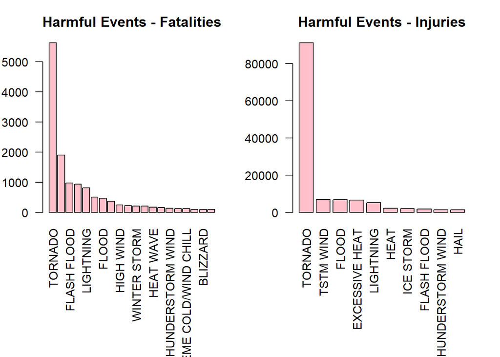

```r
par(mfrow=c(1,2),mar=c(10,3,3,2))
barplot(fatalInjuries$FATALITIES,names.arg=fatalInjuries$EVTYPE,las=2,col="pink",ylab="Fatalities",main="Harmful Events - Fatalities")

barplot(Injury$INJURIES,names.arg=Injury$EVTYPE,las=2,col="pink",ylab="injuries",main="Harmful Events - Injuries")
```

## **Health Assessment**

### 2.With respect to the Ecomonic Consequneces, there are two damages caused: **Property and Crop Damage**.

#### Property damage(PROPDMG) and Crop damage(CROPDMG) columns has another column(exponents) related to it, i.e PROPDMGEXP and CROPDMGEXP respectively. So, for the calculation of the total property and crop damages caused, we need to convert the exponent columns into numeric data.

#### Converting the magnitude into the multiplier used for calculating damage amount.

Using the following key to identify the multiplier for the orders of magnitude. 1. o(one) = 1 2. h(undred)=100 3. k(thousand)=1000 4. m(million)=1000000 5. b(billion)=1000000000

```r
storm$PROPDMG[storm$PROPDMGEXP == "K"] <- storm$PROPDMG[storm$PROPDMGEXP == "K"] * 1000
storm$PROPDMG[storm$PROPDMGEXP == "M"] <- storm$PROPDMG[storm$PROPDMGEXP == "M"] * (10^6)
storm$PROPDMG[storm$PROPDMGEXP == "H"] <- storm$PROPDMG[storm$PROPDMGEXP == "H"] * 100
storm$PROPDMG[storm$PROPDMGEXP == "h"] <- storm$PROPDMG[storm$PROPDMGEXP == "h"] * 100
storm$PROPDMG[storm$PROPDMGEXP == ""] <- storm$PROPDMG[storm$PROPDMGEXP == ""] * 1
storm$PROPDMG[storm$PROPDMGEXP == "B"] <- storm$PROPDMG[storm$PROPDMGEXP == "B"] * (10^9)
storm$PROPDMG[storm$PROPDMGEXP == "m"] <- storm$PROPDMG[storm$PROPDMGEXP == "m"] * (10^6)
storm$PROPDMG[storm$PROPDMGEXP == "0"] <- storm$PROPDMG[storm$PROPDMGEXP == "0"] * 1
storm$PROPDMG[storm$PROPDMGEXP == "1"] <- storm$PROPDMG[storm$PROPDMGEXP == "1"] * 10
storm$PROPDMG[storm$PROPDMGEXP == "2"] <- storm$PROPDMG[storm$PROPDMGEXP == "2"] * 100
storm$PROPDMG[storm$PROPDMGEXP == "3"] <- storm$PROPDMG[storm$PROPDMGEXP == "3"] * 1000
storm$PROPDMG[storm$PROPDMGEXP == "4"] <- storm$PROPDMG[storm$PROPDMGEXP == "4"] * (10^4)
storm$PROPDMG[storm$PROPDMGEXP == "5"] <- storm$PROPDMG[storm$PROPDMGEXP == "5"] * (10^5)
storm$PROPDMG[storm$PROPDMGEXP == "6"] <- storm$PROPDMG[storm$PROPDMGEXP == "6"] * (10^6)
storm$PROPDMG[storm$PROPDMGEXP == "7"] <- storm$PROPDMG[storm$PROPDMGEXP == "7"] * (10^7)
storm$PROPDMG[storm$PROPDMGEXP == "8"] <- storm$PROPDMG[storm$PROPDMGEXP == "8"] * (10^8)
storm$PROPDMG[storm$PROPDMGEXP == "+"] <- 0
storm$PROPDMG[storm$PROPDMGEXP == "-"] <- 0
storm$PROPDMG[storm$PROPDMGEXP == "?"] <- 0
head(storm[,c("EVTYPE","PROPDMG","PROPDMGEXP")])
```

```
##    EVTYPE PROPDMG PROPDMGEXP
## 1 TORNADO   25000          K
## 2 TORNADO    2500          K
## 3 TORNADO   25000          K
## 4 TORNADO    2500          K
## 5 TORNADO    2500          K
## 6 TORNADO    2500          K
```

```r
storm$CROPDMG[storm$CROPDMGEXP == "M"] <- storm$CROPDMG[storm$CROPDMGEXP == "M"] * (10^6)
storm$CROPDMG[storm$CROPDMGEXP == "K"] <- storm$CROPDMG[storm$CROPDMGEXP == "K"] * 1000
storm$CROPDMG[storm$CROPDMGEXP == "m"] <- storm$CROPDMG[storm$CROPDMGEXP == "m"] * (10^6)
storm$CROPDMG[storm$CROPDMGEXP == "B"] <- storm$CROPDMG[storm$CROPDMGEXP == "B"] * (10^9)
storm$CROPDMG[storm$CROPDMGEXP == "k"] <- storm$CROPDMG[storm$CROPDMGEXP == "k"] * 1000
storm$CROPDMG[storm$CROPDMGEXP == "0"] <- storm$CROPDMG[storm$CROPDMGEXP == "0"] * 1
storm$CROPDMG[storm$CROPDMGEXP == "2"] <- storm$CROPDMG[storm$CROPDMGEXP == "2"] * 100
storm$CROPDMG[storm$CROPDMGEXP == ""] <- storm$CROPDMG[storm$CROPDMGEXP == ""] * 1
storm$CROPDMG[storm$CROPDMGEXP == "?"] <- 0
head(storm[,c("EVTYPE","CROPDMG","CROPDMGEXP")])
```

```
##    EVTYPE CROPDMG CROPDMGEXP
## 1 TORNADO       0
## 2 TORNADO       0
## 3 TORNADO       0
## 4 TORNADO       0
## 5 TORNADO       0
## 6 TORNADO       0
```

#### Property Damage

```r
propdmg <- aggregate(PROPDMG~EVTYPE,data=storm,FUN=sum,na.rm=TRUE)
propdmg <- propdmg[with(propdmg,order(-PROPDMG)),]
propdmg <- head(propdmg,10)
print(propdmg)
```

```
##                EVTYPE      PROPDMG
## 170             FLOOD 144657709807
## 411 HURRICANE/TYPHOON  69305840000
## 834           TORNADO  56947380617
## 670       STORM SURGE  43323536000
## 153       FLASH FLOOD  16822673979
## 244              HAIL  15735267513
## 402         HURRICANE  11868319010
## 848    TROPICAL STORM   7703890550
## 972      WINTER STORM   6688497251
## 359         HIGH WIND   5270046260
```

#### Crop Damage

```r
cropdmg <- aggregate(CROPDMG~EVTYPE,data=storm,FUN=sum,na.rm=TRUE)
cropdmg <- cropdmg[with(cropdmg,order(-CROPDMG)),]
cropdmg <- head(cropdmg,10)
print(cropdmg)
```

```
##                EVTYPE     CROPDMG
## 95            DROUGHT 13972566000
## 170             FLOOD  5661968450
## 590       RIVER FLOOD  5029459000
## 427         ICE STORM  5022113500
## 244              HAIL  3025954473
## 402         HURRICANE  2741910000
## 411 HURRICANE/TYPHOON  2607872800
## 153       FLASH FLOOD  1421317100
## 140      EXTREME COLD  1292973000
## 212      FROST/FREEZE  1094086000
```

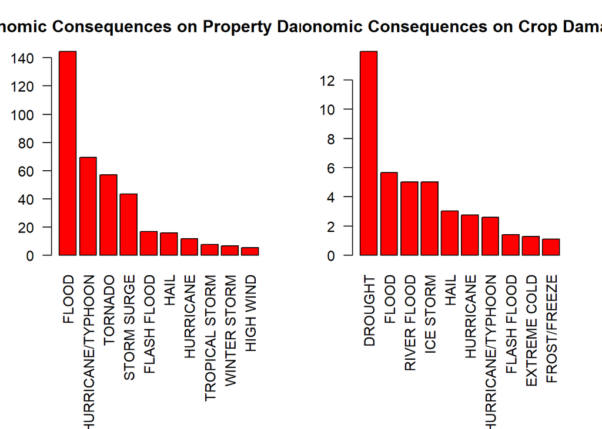

```r
par(mfrow=c(1,2),mar=c(10,3,3,2))
barplot(propdmg$PROPDMG/(10^9),names.arg=propdmg$EVTYPE,las=2,col="red",ylab="Prop.damage(billions)",main="Economic Consequences on Property Damages")
barplot(cropdmg$CROPDMG/(10^9),names.arg=cropdmg$EVTYPE,las=2,col="red",ylab="Crop damage(billions)",main="Economic Consequences on Crop Damages")
```

## **Economic Impact**

##### Drought has the largest impact on crops whereas Flooding produces the largest overall weather-related impact to the economy.